# JGausin_FINAL_forGIT

Justine Gausin

7/30/2022

# Executive summary.

According to attribute selection, Type.of.Travel, Class, Inflight.wifi.service, Online.boarding Inflight.entertainment and Checkin.service seems to influence the overall satisfaction the most. Arrival Delay and Departure Delay is contested in attribute selection, appearing important in one but not the other. Gender appears to be the least important feature with relations to overall satisfaction or any data other features.

# Preprocessing

## Library

Importing the data set here {See R Code}

## Import the Data Set.

We split the original data to train and test set to be used on the Final Project. The **AirlineSurvey_train** training set is about 80% of the original data set and the test set about 20% **AirlineSurvey_test**.

As an example we can see the features of the training data set:

```
##  [1] "X"                                 "id"
##  [3] "Gender"                            "Customer.Type"
##  [5] "Age"                               "Type.of.Travel"
##  [7] "Class"                             "Flight.Distance"
##  [9] "Inflight.wifi.service"             "Departure.Arrival.time.convenient"
## [11] "Ease.of.Online.booking"            "Gate.location"
## [13] "Food.and.drink"                    "Online.boarding"
## [15] "Seat.comfort"                      "Inflight.entertainment"
## [17] "On.board.service"                  "Leg.room.service"
## [19] "Baggage.handling"                  "Checkin.service"
## [21] "Inflight.service"                  "Cleanliness"
## [23] "Departure.Delay.in.Minutes"        "Arrival.Delay.in.Minutes"
## [25] "satisfaction"
```

## Clean Data sets for any missing values

There are 310 number of rows with missing data for some columns in the training set. Likewise there are 83 number of rows with missing data for some columns in the test set.

We remove the following missing data {See R code}:

In conclusion, after cleaning. We got the following table for the training and test sets:

For the train set:

```
##            [,1]       [,2]        [,3]
## Train_set  "Original" "NA values" "Post-Sanitization"
## NumberRows "103904"   "310"       "103594"
```

For the test set:

```
##          [,1]       [,2]        [,3]
## Test_set "Original" "NA values" "Post-Sanitization"
## Rowsr    "25976"    "83"        "25893"
```

# Step 1: Statistics on departure delay (A8) and arrival delay (A9).

First we create a function in R to find the mode, shown below:

```r
#Create a function that finds the mode
Mode <- function(x) {
  ux <- unique(x)
  ux[which.max(tabulate(match(x, ux)))]
}
```

For the mean and median, We will use the *summary* built-in function in R.

## 1a. For features A8 and A9, determine:

### i. Central tendency measures: mean, mode, and median (for each)

The mean, median , and mode for **Departure.Delay.in.Minutes**:

```
##    Min. 1st Qu.  Median    Mean 3rd Qu.    Max.
##    0.00    0.00    0.00   14.75   12.00 1592.00
```

```
## The mode of the Departure Delay in Minutes is:  0
```

The mean, median , and mode for **Arrival.Delay.in.Minutes**:

```
##    Min. 1st Qu.  Median    Mean 3rd Qu.    Max.
##    0.00    0.00    0.00   15.18   13.00 1584.00
```

```
## The mode of the Arrival Delay in Minutes is:  0
```

### ii. The spread: standard deviation (for each)

We can find the standard deviation of the feature using the *sd* function in R:

```
## The std for Departure.Delay.in.Minutes:  38.11674
```

```
## The std for Arrival.Delay.in.Minutescs:  38.69868
```

### iii. Percentiles: the 10 th, 50 th, 75 th and 90 th percentiles (for each)

R offers a function referred to as *quantile* to determine the percentiles. However, we would need to input the .10, .50, .75th and .90 as values, since they are not the default percentiles.

The following table display the *percentile* for **Arrival.Delay.in.Minutes** and **Departure.Delay.in.Minutes**:

```
##                          10% 50% 75% 90%
## Arrival.delay.Quartile     0   0  13  44
## Departure.delay.Quartile   0   0  12  44
```

### iv. 1st quartile, 3rd quartile, and the median

We will use the *summary* function again available in R to display the 1st quartile, 3rd quartile, and the median:

```
##                   Min. 1st Qu. Median     Mean 3rd Qu. Max.
## departure_summary    0       0      0 14.74794      12 1592
## arrival_summary      0       0      0 15.17868      13 1584
```

### v. The skewness (for each)

R offers the *skewness* function that can be used to determine the skewness of the features:

The following table display the *skewness* for **Arrival.Delay.in.Minutes** and **Departure.Delay.in.Minutes**:

```
##                              [,1]
## Departure.delay.Skewness 6.596446
## Arrival.delay.Skewness   6.768853
```

### vi. The covariance and correlation between A8 and A9

R offers the *covariance* and *correlation* functions that can be used to determine the covariance and correlation of the features, respectively:

The following table display the *covariance* and *correlation* for **Arrival.Delay.in.Minutes** and **Departure.Delay.in.Minutes**:

```
##                           [,1]
## covariance.A8wA9  1424.1494855
## correlation.A8wA9    0.9654809
```

### vii. Plot the two delays on a chart to display their distributions https://www.webdatarocks.com/blog/best-charts-for-data-distribution/

Plotting the distribution in a histogram in R:

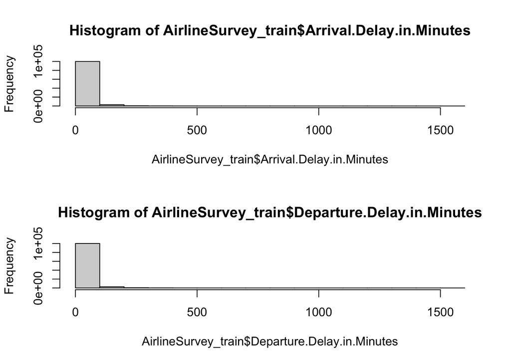

## 1b. Based on the above results in 1a, make useful conclusions. This is an important part of data analysis. It should be an English description that non-mathematically oriented airline executives can understand.

There is a very strong correlation between A8 and A9, with the value of 0.9654809. Since the value of skewness for both A8 and A9 is greater than 1, it can be said that the distribution is highly skewed. This conclusion is reinforced by the histogram, where most of the values are more distributed in the left side of the graph. While the maximum value of the delay and arrival is above 1500 minutes (about 25 hours), the average delay is close to 15 minutes. While arrival and delay should be close to zero for punctuality, an average delay of 15 minutes is quite small compare to the logistics involve.

# Step 2: Discretize some features

## a. Convert numerical values to categorical values:

### i. Discretize age (A3) to nominal values using the following criteria: 0-15: Child; 16-35: Youth; 36-55 Middle age; 56-70: Old; >70- Senior;

We discretize the following values in *R*, and store the new categorical (nominal) values as a new feature called **Age.cat** in the **AirlineSurvey_train** training set.

The following shows the distribution (in alphabetical order) of the new discretize feature **Age.cat**:

```
##     Child MiddleAge       Old    Senior     Youth
##      6024     45379     16135       755     35301
```

### ii. Discretize flight distance (A7) to nominal values using the following criteria: 0-500 miles: Short haul; 501-3000 miles: Medium haul; >3000 Long haul

We discretize the following values in R, and store the new categorical (nominal) values as a new feature called **flightDistance.cat** in the **AirlineSurvey_train** training set.

The following shows the distribution (in alphabetical order) of the new discretize feature **flightDistance.cat**:

```
##   LongHaul MediumHaul  ShortHaul
##       8248      63109      32237
```

### iii. Discretize delays (A8 and A9) to nominal values: Small: 0-15; Medium: 16-45; Long: >45

We discretize the following values in R, and store the new categorical (nominal) values as a new feature called **Departure.Delay.cat** in the **AirlineSurvey_train** training set.

The following shows the distribution (in alphabetical order) of the new discretize feature **Departure.Delay.cat**:

```
##   Long Medium  Small
##   9879  13037  80678
```

We discretize the following values in R, and store the new categorical (nominal) values as a new feature called **Arrival.Delay.cat** in the **AirlineSurvey_train** training set.

The following shows the distribution (in alphabetical order) of the new discretize feature **Arrival.Delay.cat**:

```
##   Long Medium  Small
##  10066  13569  79959
```

### iv. Plot the distributions for each of the above using the discretized values.

PLotting the following distributions using the *ggplot* function in R:

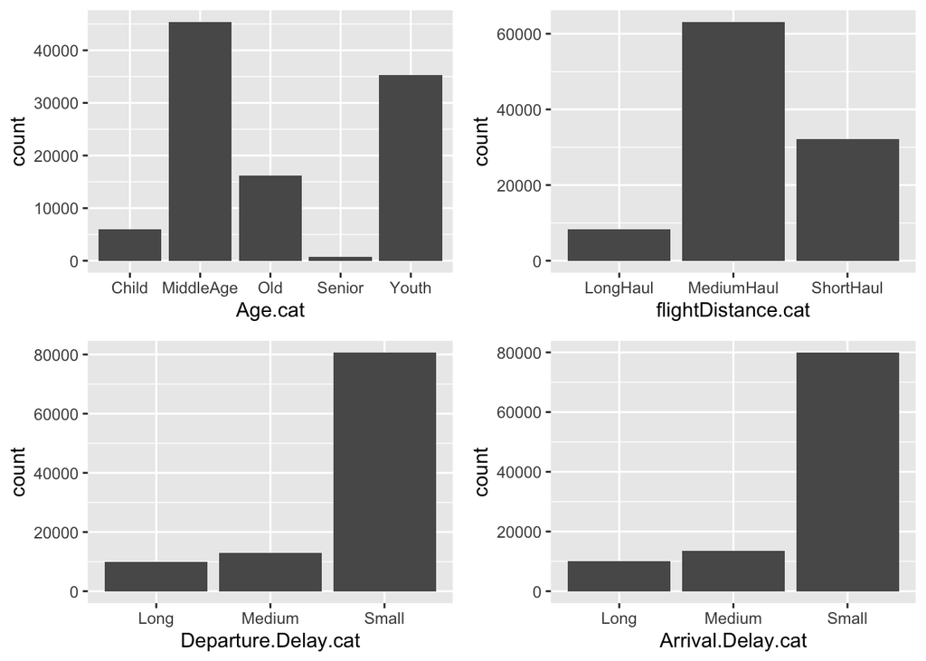

As seen in Step 1, a majority of the **Departure.Delay.in,Minutes** and **Arrival.Delay.in.Minutes** are relatively small delays. Step 2, reinforces the same finding. According to the categorical Age, a majority of travelers are either **Youth** or **Middle Age**, that is, the range of 16-56 years old. Likewise, a majority of the distance of flights are Medium Haul or 500-3000 miles long.

# Step 3.

## Test the following two hypotheses. Show evidence to show whether they are true or false.

Factorize quality features needed for the problem in train set: {Not Shown, see R code }

Factorize quality features needed for the problem in test set: {Not Shown, see R code }

## 3H1: Long haul passengers’ overall satisfaction is influenced more by the in-flight service quality than by the departure delays.

First, we create new Long Haul List by filtering the **AirlineSurvey_train** training set into a new data frame called **Long.Haul.Passenger**.

The dimension of the **Long.Haul.Passenger**:

```
## [1] 8248   29
```

The number of rows should be equivalent to the Long Haul summary statistics in Step 2 (ii).

Next, we examine the following relationships between Long Haul’s travelers **overall satisfaction** against **Departure.Delay.in.Minutes** and Long Haul’s **overall satisfaction** against **Inflight.service**. Since the **overall satisfaction** is a nominal value, we would need to use Classification methods. In this step, we use *Logistic Regression* to compare the relationship.

The relationship between **overall satisfaction** against **Departure.Delay.in.Minutes**:

```
##
## Call:
## glm(formula = satisfaction ~ Departure.Delay.in.Minutes, family = binomial,
##     data = Long.Haul.Passenger)
##
## Deviance Residuals:
##     Min       1Q   Median       3Q      Max
## -1.7538   0.6955   0.6955   0.7016   1.4833
##
## Coefficients:
##                              Estimate Std. Error z value Pr(>|z|)
## (Intercept)                 1.2961490  0.0285069  45.468  < 2e-16 ***
## Departure.Delay.in.Minutes -0.0039751  0.0006114  -6.502 7.93e-11 ***
## ---
## Signif. codes:  0 '***' 0.001 '**' 0.01 '*' 0.05 '.' 0.1 ' ' 1
##
## (Dispersion parameter for binomial family taken to be 1)
##
##     Null deviance: 8817.8  on 8247  degrees of freedom
## Residual deviance: 8776.4  on 8246  degrees of freedom
## AIC: 8780.4
##
## Number of Fisher Scoring iterations: 4
```

The relationship between **overall satisfaction** against **Inflight.service**:

```
##
## Call:
## glm(formula = satisfaction ~ Inflight.service, family = binomial,
##     data = Long.Haul.Passenger)
##
## Deviance Residuals:
##     Min       1Q   Median       3Q      Max
## -3.0863   0.1310   0.1310   0.5321   1.3795
##
## Coefficients:
##                   Estimate Std. Error z value Pr(>|z|)
## (Intercept)         -11.57     196.97  -0.059    0.953
## Inflight.service1    11.10     196.97   0.056    0.955
## Inflight.service2    11.26     196.97   0.057    0.954
## Inflight.service3    11.48     196.97   0.058    0.954
## Inflight.service4    13.45     196.97   0.068    0.946
## Inflight.service5    16.32     196.97   0.083    0.934
##
## (Dispersion parameter for binomial family taken to be 1)
##
##     Null deviance: 8817.8  on 8247  degrees of freedom
## Residual deviance: 6203.9  on 8242  degrees of freedom
## AIC: 6215.9
##
## Number of Fisher Scoring iterations: 10
```

## 3H2. Medium haul passengers’ overall satisfaction is influenced more by the arrival delays than by the in-flight entertainment.

First, we create new List by filtering the **AirlineSurvey_train** training set into a new data frame called **Medium.Haul.Passenger**.

The dimension of the **Medium.Haul.Passenger**:

```
## [1] 63109    29
```

The number of rows should be equivalent to the Medium Haul summary statistics in Step 2 (ii).

Next, we examine the following relationships between Medium Haul’s travelers **overall satisfaction** against **Arrival.Delay.in.Minutes** and Medium Haul’s **overall satisfaction** against **Inflight.entertainment**. Since the **overall satisfaction** is a nominal value, we would need to use Classification methods. In this step, we use *Logistic Regression* to compare the relationship.

The relationship between **overall satisfaction** against **Arrival.Delay.in.Minutes**:

```
##
## Call:
## glm(formula = satisfaction ~ Arrival.Delay.in.Minutes, family = binomial,
##     data = Medium.Haul.Passenger)
##
## Deviance Residuals:
##    Min      1Q  Median      3Q     Max
## -1.095  -1.095  -1.040   1.262   2.833
##
## Coefficients:
##                            Estimate Std. Error z value Pr(>|z|)
## (Intercept)              -0.1968598  0.0086762  -22.69   <2e-16 ***
## Arrival.Delay.in.Minutes -0.0029660  0.0002307  -12.86   <2e-16 ***
## ---
## Signif. codes:  0 '***' 0.001 '**' 0.01 '*' 0.05 '.' 0.1 ' ' 1
##
## (Dispersion parameter for binomial family taken to be 1)
##
##     Null deviance: 86579  on 63108  degrees of freedom
## Residual deviance: 86397  on 63107  degrees of freedom
## AIC: 86401
##
## Number of Fisher Scoring iterations: 4
```

The relationship between **overall satisfaction** against **Inflight.entertainment**:

```
##
## Call:
## glm(formula = satisfaction ~ Inflight.entertainment, family = binomial,
##     data = Medium.Haul.Passenger)
##
## Deviance Residuals:
##     Min       1Q   Median       3Q      Max
## -1.4564  -0.8061  -0.5406   0.9776   1.9978
##
## Coefficients:
##                         Estimate Std. Error z value Pr(>|z|)
## (Intercept)              -10.566     42.238  -0.250    0.802
## Inflight.entertainment1    8.717     42.238   0.206    0.837
## Inflight.entertainment2    9.328     42.238   0.221    0.825
## Inflight.entertainment3    9.608     42.238   0.227    0.820
## Inflight.entertainment4   11.056     42.238   0.262    0.794
## Inflight.entertainment5   11.201     42.238   0.265    0.791
##
## (Dispersion parameter for binomial family taken to be 1)
##
##     Null deviance: 86579  on 63108  degrees of freedom
## Residual deviance: 74686  on 63103  degrees of freedom
## AIC: 74698
##
## Number of Fisher Scoring iterations: 9
```

## 3H3. Make your own hypothesis, state it, and test it.

Satisfaction is influenced by the combination of arrival delay time and departure delay time for all passengers.

```
##
## Call:
## glm(formula = satisfaction ~ Arrival.Delay.in.Minutes + Departure.Delay.in.Minutes,
##     family = binomial, data = AirlineSurvey_train)
##
## Deviance Residuals:
##    Min      1Q  Median      3Q     Max
## -1.162  -1.085  -1.020   1.272   2.894
##
## Coefficients:
##                              Estimate Std. Error z value Pr(>|z|)
## (Intercept)                -0.2201797  0.0067958 -32.400  < 2e-16 ***
## Arrival.Delay.in.Minutes   -0.0072306  0.0006531 -11.071  < 2e-16 ***
## Departure.Delay.in.Minutes  0.0040626  0.0006599   6.157 7.43e-10 ***
## ---
## Signif. codes:  0 '***' 0.001 '**' 0.01 '*' 0.05 '.' 0.1 ' ' 1
##
## (Dispersion parameter for binomial family taken to be 1)
##
##     Null deviance: 141768  on 103593  degrees of freedom
## Residual deviance: 141360  on 103591  degrees of freedom
## AIC: 141366
##
## Number of Fisher Scoring iterations: 4
```

# Step 4.

## Find associations between some of the important attributes.

## 4a. With Gender, Age, Type of travel, Flight distance, Class, Arrival delays, and Overall satisfaction as attributes, determine association rules with a minimum support of 100 and a minimum confidence of 60%.

In this step, we will use **Weka** to compute the association rules using the **Apriori** rule in the Associate Tab.

=== === === === === === === === Summary === === === === === === === ===  
Minimum support: 0.4 (41438 instances)

Minimum metric : 0.6 Number of cycles performed: 12  
Generated sets of large itemsets:  
Size of set of large itemsets L(1): 10  
Size of set of large itemsets L(2): 8  
Best rules found:

1. Class=Business 49533 ==> Customer.Type=Loyal Customer 42191 <conf:(0.85)> lift:(1.04) lev:(0.02) [1710] conv:(1.23)
2. Gender=Male 51018 ==> Customer.Type=Loyal Customer 42326 <conf:(0.83)> lift:(1.02) lev:(0.01) [631] conv:(1.07)
3. flightDistance.cat=MediumHaul 63109 ==> Customer.Type=Loyal Customer 52024 <conf:(0.82)> lift:(1.01) lev:(0) [448] conv:(1.04)
4. Arrival.Delay.cat=Small 79959 ==> Customer.Type=Loyal Customer 65444 <conf:(0.82)> lift:(1) lev:(0) [97] conv:(1.01)
5. Gender=Female 52576 ==> Customer.Type=Loyal Customer 42336 <conf:(0.81)> lift:(0.99) lev:(-0.01) [-631] conv:(0.94)
6. Customer.Type=Loyal Customer 84662 ==> Arrival.Delay.cat=Small 65444 <conf:(0.77)> lift:(1) lev:(0) [97] conv:(1.01)
7. flightDistance.cat=MediumHaul 63109 ==> Arrival.Delay.cat=Small 48593 <conf:(0.77)> lift:(1) lev:(-0) [-117] conv:(0.99)
8. satisfaction=neutral or dissatisfied 58697 ==> Customer.Type=Loyal Customer 44249 <conf:(0.75)> lift:(0.92) lev:(-0.04) [-3721] conv:(0.74)
9. satisfaction=neutral or dissatisfied 58697 ==> Arrival.Delay.cat=Small 43458 <conf:(0.74)> lift:(0.96) lev:(-0.02) [-1847] conv:(0.88)
10. Customer.Type=Loyal Customer 84662 ==> flightDistance.cat=MediumHaul 52024 <conf:(0.61)> lift:(1.01) lev:(0) [448] conv:(1.01)

=== === === === === === === === === === === === === === === === ===

# Step 5 Reduce the satisfaction features using PCA.

## 5a. Using PCA (Principal Component Analysis), combine features A10-A23 into a single feature. Let us call it PCAS. Now find average, minimum, and maximum of A10-A23 (computed for each passenger record). Let us call them AVES, MINS, and MAXS, respectively. Convert A24 (overall satisfaction) into a numeric value by converting neutral or unsatisfied to 1.0 and satisfied to 4. Let us call it DA24.

We use **Weka** for the following step. USING PCA for the training set, we found the following AVES, MIN, and MAX for the first component in the rank (We remove all others): Rank1: Variance: .9399 {MIN: -5.698, MAX: 4.777, MEAN: 0, STD: 2.233}

## 5b. Which among PCAS, AVES, MINS, and MAXS could be used as proxy (or proxies) for DA24? You need to make some runs to answer this question.

We use the first components analysis on the following classifier:

*Logistic Regression*:

| Summary |  |  |
| --- | --- | --- |
| Correctly Classified Instances | 14528 | 56.1078 % |
| Incorrectly Classified Instances | 11365 | 43.8922 % |

*AdaBoostM1*:

| Summary |  |  |
| --- | --- | --- |
| Correctly Classified Instances | 14528 | 56.1078 % |
| Incorrectly Classified Instances | 11365 | 43.8922 % |

Using the training set instead of the test set, we get the following summary using the cross validation of 10 folds:

Time taken to build model: 0.66 seconds

*Stratified cross-validation*:

| Summary |  |  |
| --- | --- | --- |
| Correctly Classified Instances | 79951 | 77.1772 % |
| Incorrectly Classified Instances | 23643 | 22.8228 % |

*FINDING*: *Stratified Cross-validation* shows a significant accuracy. However, that is only due the fact that the cross validation was done using the training set. Both *AdaBoostM1* and *Logistic Regression* used the training set and used the test set.

## 5c. What benefit, if any, is derived by using PCAS from A10-A23? Is there any additional benefit if we had derived three components from PCA instead of just one? Show some evidence to justify your answer. (Hint: Repeat PCA in 5a with 3 components and then answer the question.)

PCAS reduces the complexity of the features while retaining the relationship of the features. The following top 3 components/ranks were used: Rank1: {MIN: -5.698, MAX: 4.777, MEAN: 0, STD: 2.233}

Rank2: {MIN: -5.596, MAX: 4.652, MEAN: 0, STD: 2.003}

Rank3: {MIN: -4.678, MAX: 6.565, MEAN: 0, STD: 1.941}

If we use the following 3 components we get the following results:

Using *Logistic Regression* with the supplied test set:

| Summary |  |  |
| --- | --- | --- |
| Correctly Classified Instances | 14528 | 56.1078 % |
| Incorrectly Classified Instances | 11365 | 43.8922 % |

No apparent increase in accuracy on the test set

If we train it in the training set instead:

| Summary |  |  |
| --- | --- | --- |
| Correctly Classified Instances | 80100 | 77.3211 % |
| Incorrectly Classified Instances | 23494 | 22.6789 % |
| Kappa statistic | 0.5387 |  |

If we use the training set again, but with crossvalidation of 10.

=== Stratified cross-validation ===

| Summary |  |  |
| --- | --- | --- |
| Correctly Classified Instances | 80106 | 77.3269 % |
| Incorrectly Classified Instances | 23488 | 22.6731 % |

There does not seem to be a high increase in accuracy if we use three components instead of one.

# Step 6.

## a. Using linear regression, model the relationship between (i) flight distance (in miles) and arrival delay (in minutes), and (ii) flight distance (in miles) and departure delay (in minutes). Explain the derived models and their accuracy. State whether such a relationship makes sense based on the derived models.

### i. flight distance (in miles) and arrival delay (in minutes)

In the following step, we will use a general linear regression to explore the relationship between **Arrival.Delay.in.Minutes** and **Flight.Distance** in the **AirlineSurvey_train** data set.

The summary shows:

```
##
## Call:
## lm(formula = Arrival.Delay.in.Minutes ~ Flight.Distance, data = AirlineSurvey_train)
##
## Residuals:
##     Min      1Q  Median      3Q     Max
##  -15.29  -15.22  -15.04   -2.20 1568.81
##
## Coefficients:
##                   Estimate Std. Error t value Pr(>|t|)
## (Intercept)      1.529e+01  1.871e-01  81.713   <2e-16 ***
## Flight.Distance -9.413e-05  1.206e-04  -0.781    0.435
## ---
## Signif. codes:  0 '***' 0.001 '**' 0.01 '*' 0.05 '.' 0.1 ' ' 1
##
## Residual standard error: 38.7 on 103592 degrees of freedom
## Multiple R-squared:  5.885e-06,  Adjusted R-squared:  -3.769e-06
## F-statistic: 0.6096 on 1 and 103592 DF,  p-value: 0.4349
```

The Pr(>|t|) indicates that there is little to no relationship between the two features. Likewise, the R^2 value is close to 0.

### ii. flight distance (in miles) and departure delay (in minutes)

In the following step, we will use a general linear regression to explore the relationship between **Departure.Delay.in.Minutes** and **Flight.Distance** in the **AirlineSurvey_train** data set.

The summary shows:

```
##
## Call:
## lm(formula = Departure.Delay.in.Minutes ~ Flight.Distance, data = AirlineSurvey_train)
##
## Residuals:
##     Min      1Q  Median      3Q     Max
##  -15.02  -14.73  -14.68   -2.70 1577.26
##
## Coefficients:
##                  Estimate Std. Error t value Pr(>|t|)
## (Intercept)     1.466e+01  1.843e-01  79.546   <2e-16 ***
## Flight.Distance 7.284e-05  1.187e-04   0.613     0.54
## ---
## Signif. codes:  0 '***' 0.001 '**' 0.01 '*' 0.05 '.' 0.1 ' ' 1
##
## Residual standard error: 38.12 on 103592 degrees of freedom
## Multiple R-squared:  3.632e-06,  Adjusted R-squared:  -6.021e-06
## F-statistic: 0.3762 on 1 and 103592 DF,  p-value: 0.5396
```

*FINDING*: **Flight.Distance** was not a strong predictor for Departure and Arrival Delay. Arrival Delay and Departure Delay is a type of exponential problem where the waiting time is “memory-less”. Hence, linear regression would fail to fit the model.

# Step 7.

## Using any of the data mining techniques you are familiar with, answer the following questions. Show your work to justify your conclusions.

## 7a. Is satisfaction with seat comfort related (or depends on) to passenger Gender?

We will try to examine the relationship with seat comfort and Gender based on a Naive bayes classifier using the training and the test set.

*Naive Bayes Classifier*

| Summary |  |  |
| --- | --- | --- |
| Correctly Classified Instances | 7969 | 30.7767 % |
| Incorrectly Classified Instances | 17924 | 69.2233 % |

In *RandomTree*:

| Summary |  |  |
| --- | --- | --- |
| Correctly Classified Instances | 7969 | 30.7767 % |
| Incorrectly Classified Instances | 17924 | 69.2233 % |

*FINDING*:There does not seem to be a relationship between **Gender** and **seat comfort**.

## 7b. Is satisfaction with gate location related to passenger age?

Let’s examine passenger age (numerical) and gate location satisfaction:  
Using decision trees in **Weka**, we got the following results:

Using *J48* we got the following statistics:

| Summary |  |  |
| --- | --- | --- |
| Correctly Classified Instances | 7122 | 27.5055 % |
| Incorrectly Classified Instances | 18771 | 72.4945 % |
| Kappa statistic | 0 |  |
| Mean absolute error | 0.2626 |  |
| Root mean squared error | 0.3624 |  |
| Relative absolute error | 99.9997 % |  |
| Root relative squared error | 100 % |  |
| Total Number of Instances | 25893 |  |

## 7c. Do first time passengers have more or less expectations than returning customers measured in terms of overall satisfaction?

Using *Naive Bayes*, we can see that:

```
                                    Class
```

| Attribute | neutral or dissatisfied | satisfied |
| --- | --- | --- |
| ~ | (0.57) | (0.43) |
| Customer.Type |  |  |
| + Loyal Customer | 44250.0 | 40414.0 |
| + disloyal Customer | 14449.0 | 4485.0 |
| [total] | 58699.0 | 44899.0 |

*FINDING*: From the split, we can see that Disloyal Customers (First-time?) are more likely to be dissatisfied than Loyal customers. About 14449.0/(14449.0+4485.0) = 0.76 = 76% of disloyal customers are neutral or dissatisfied and 44250.0/(44250.0+40414.0) = .52 = 52% of loyal customers are neutral or dissatisfied.

## 7d. Is there a distinct (statistically significant) difference between business and personal travelers (A5) in terms of their reaction to their flights? (Hint: Use any attribute(s) that you think appropriate to measure their reaction.)

The most appropriate to measure for business and personal travelers is A10 (Departure and Arrival Time Satisfaction). Business travelers are more in a time constraints than personal travelers. Hence, a flight that is punctual would be highly rated for business travelers. Let’s examine:

*Naive Bayes Classifier*

```
                  Class
```

| Attribute | 0 | 1 | 2 | 3 | 4 | 5 |
| --- | --- | --- | --- | --- | --- | --- |
| ~ | (0.05) | (0.15) | (0.17) | (0.17) | (0.25) | (0.22) |
| Type.of.Travel |  |  |  |  |  |  |
| + Personal Travel | 869.0 | 2716.0 | 3046.0 | 3785.0 | 11436.0 | 10283.0 |
| + Business travel | 4423.0 | 12738.0 | 14098.0 | 14120.0 | 14040.0 | 12052.0 |
| [total] | 5292.0 | 15454.0 | 17144.0 | 17905.0 | 25476.0 | 22335.0 |

Let’s examine overall satisfaction instead:  
Using *Naive Byes Classifier*, the split:

```
                                     Class
```

| Attribute | neutral or dissatisfied | satisfied |
| --- | --- | --- |
| ~ | (0.57) | (0.43) |
| Type.of.Travel |  |  |
| + Personal Travel | 28867.0 | 3264.0 |
| + Business travel | 29832.0 | 41635.0 |
| [total] 58699.0 | 44899.0 |  |

*FINDING*: Now there is a clear distinct difference between personal and business travel. Personal travelers tend to be more neutral or dissatisfied (28867.0/(28867.0+3264.0)) = 90% and among Business travelers, they tend to be more satisfied overall (41635.0/(29832.0+41635.0)) = 58%.

## 7e. Is there a distinct (statistically significant) difference between business class passengers and economy passengers (A6) in terms of their reaction to satisfaction with food-and-drink?

*Naive Bayes Classifier*

```
                            Class
```

| Attribute | 0 | 1 | 2 | 3 | 4 | 5 |
| --- | --- | --- | --- | --- | --- | --- |
| ~ | (0) | (0.12) | (0.21) | (0.21) | (0.23) | (0.21) |
| Class |  |  |  |  |  |  |
| + Eco Plus | 19.0 | 1102.0 | 1552.0 | 1591.0 | 1690.0 | 1520.0 |
| + Business | 32.0 | 4359.0 | 10570.0 | 10702.0 | 12380.0 | 11496.0 |
| + Eco | 57.0 | 7342.0 | 9799.0 | 9948.0 | 10227.0 | 9226.0 |
| [total] | 108.0 | 12803.0 | 21921.0 | 22241.0 | 24297.0 | 22242.0 |

*FINDING*: No distribution difference between the classes with the food-and-drink satisfaction. The minor key difference in the distribution; Business class has a lower count (relative to its class) when rating the food-and-drink satifaction as *1*.

# Step 8.

## 8a. Determine if any relationship exists between check-in service (A12) and baggage handling (A23) using any data mining technique. Based on this, provide a guidance to airline executives.

Using *J48*:

| Summary |  |  |
| --- | --- | --- |
| Correctly Classified Instances | 7254 | 28.0153 % |
| Incorrectly Classified Instances | 18639 | 71.9847 % |
| Kappa statistic | 0 |  |
| Mean absolute error | 0.259 |  |
| Root mean squared error | 0.3599 |  |
| Relative absolute error | 99.9996 % |  |
| Root relative squared error | 100 % |  |
| Total Number of Instances | 25893 |  |

Using *RandomTree*:

| Summary |  |  |
| --- | --- | --- |
| Correctly Classified Instances | 7279 | 28.1118 % |
| Incorrectly Classified Instances | 18614 | 71.8882 % |
| Kappa statistic | 0.0023 |  |
| Mean absolute error | 0.2548 |  |
| Root mean squared error | 0.3569 |  |
| Relative absolute error | 98.3792 % |  |
| Root relative squared error | 99.1746 % |  |
| Total Number of Instances | 25893 |  |

Using *LogitBoost*:

| Summary |  |  |
| --- | --- | --- |
| Correctly Classified Instances | 7277 | 28.1041 % |
| Incorrectly Classified Instances | 18616 | 71.8959 % |
| Kappa statistic | 0.0038 |  |
| Mean absolute error | 0.2548 |  |
| Root mean squared error | 0.3569 |  |
| Relative absolute error | 98.3956 % |  |
| Root relative squared error | 99.1755 % |  |
| Total Number of Instances | 25893 |  |

Using *Naive Bayes*:

| Summary |  |  |
| --- | --- | --- |
| Correctly Classified Instances | 7279 | 28.1118 % |
| Incorrectly Classified Instances | 18614 | 71.8882 % |
| Kappa statistic | 0.0023 |  |
| Mean absolute error | 0.2548 |  |
| Root mean squared error | 0.3569 |  |
| Relative absolute error | 98.38 % |  |
| Root relative squared error | 99.1746 % |  |
| Total Number of Instances | 25893 |  |

Overall there doesn’t seem to be a relationship with check-in service (A12) and baggage handling (A23).

## 8b. Between A10 and A16, which one do you think passengers value the most? Assume that the overall satisfaction (A24) is a good proxy for the value.

Departure and arrival time satisfaction vs overall satisfaction:

Using *Random Forest*:

| Summary |  |  |
| --- | --- | --- |
| Correctly Classified Instances | 14528 | 56.1078 % |
| Incorrectly Classified Instances | 11365 | 43.8922 % |
| Kappa statistic | 0 |  |
| Mean absolute error | 0.4894 |  |
| Root mean squared error | 0.4949 |  |
| Relative absolute error | 99.4982 % |  |
| Root relative squared error | 99.7166 % |  |
| Total Number of Instances | 25893 |  |

*OneR*:

| Summary |  |  |
| --- | --- | --- |
| Correctly Classified Instances | 14528 | 56.1078 % |
| Incorrectly Classified Instances | 11365 | 43.8922 % |
| Kappa statistic | 0 |  |
| Mean absolute error | 0.4389 |  |
| Root mean squared error | 0.6625 |  |
| Relative absolute error | 89.2364 % |  |
| Root relative squared error | 133.4939 % |  |
| Total Number of Instances | 25893 |  |

*AdaBoost1*:

| Summary |  |  |
| --- | --- | --- |
| Correctly Classified Instances | 14528 | 56.1078 % |
| Incorrectly Classified Instances | 11365 | 43.8922 % |
| Kappa statistic | 0 |  |
| Mean absolute error | 0.4897 |  |
| Root mean squared error | 0.4949 |  |
| Relative absolute error | 99.5565 % |  |
| Root relative squared error | 99.7262 % |  |
| Total Number of Instances | 25893 |  |

vs

Seat Comfort satisfaction vs overall satisfaction

*Using Random Forest*:

| Summary |  |  |
| --- | --- | --- |
| Correctly Classified Instances | 17514 | 67.6399 % |
| Incorrectly Classified Instances | 8379 | 32.3601 % |
| Kappa statistic | 0.3629 |  |
| Mean absolute error | 0.419 |  |
| Root mean squared error | 0.4587 |  |
| Relative absolute error | 85.1956 % |  |
| Root relative squared error | 92.423 % |  |
| Total Number of Instances | 25893 |  |

Using *OneR*:

| Summary |  |  |
| --- | --- | --- |
| Correctly Classified Instances | 17514 | 67.6399 % |
| Incorrectly Classified Instances | 8379 32.3601 % |  |
| Kappa statistic | 0.3629 |  |
| Mean absolute error | 0.3236 |  |
| Root mean squared error | 0.5689 |  |
| Relative absolute error | 65.7908 % |  |
| Root relative squared error | 114.6232 % |  |
| Total Number of Instances | 25893 |  |

Using *AdaBoost1*:

| Summary |  |  |
| --- | --- | --- |
| Correctly Classified Instances | 17514 | 67.6399 % |
| Incorrectly Classified Instances | 8379 | 32.3601 % |
| Kappa statistic | 0.3629 |  |
| Mean absolute error | 0.4202 |  |
| Root mean squared error | 0.4588 |  |
| Relative absolute error | 85.4337 % |  |
| Root relative squared error | 92.438 % |  |
| Total Number of Instances | 25893 |  |

*FINDING*: Seat comfort had better accuracy in predicting overall satisfaction than Departure and arrival time satisfaction.

## 8EXTRA:

In this step we will use **Weka** attribute selection to rank the attributes:

*InfoGainAttributeEval*:

Ranked attributes:

| Value | Col. | Attribute |
| --- | --- | --- |
| 0.304096 | 10 | Online.boarding |
| 0.233257 | 5 | Inflight.wifi.service |
| 0.192687 | 4 | Class |
| 0.163958 | 3 | Type.of.Travel |
| 0.135373 | 12 | Inflight.entertainment |
| 0.113619 | 11 | Seat.comfort |
| 0.087677 | 14 | Leg.room.service |
| 0.082571 | 13 | On.board.service |
| 0.074691 | 18 | Cleanliness |
| 0.073303 | 7 | Ease.of.Online.booking |
| 0.06156 | 15 | Baggage.handling |
| 0.05916 | 17 | Inflight.service |
| 0.04597 | 16 | Checkin.service |
| 0.039726 | 20 | Age.cat |
| 0.03777 | 9 | Food.and.drink |
| 0.037176 | 21 | flightDistance.cat |
| 0.026794 | 2 | Customer.Type |
| 0.017381 | 8 | Gate.location |
| 0.00538 | 23 | Arrival.Delay.cat |
| 0.00364 | 22 | Departure.Delay.cat |
| 0.00314 | 6 | Departure.Arrival.time.convenient |
| 0.00011 | 1 | Gender |

*OneRAttributeEval w/ Ranker* Ranked attributes:

| Value | Col. | Attribute |
| --- | --- | --- |
| 79.0335 | 10 | Online.boarding |
| 75.2399 | 4 | Class |
| 74.2398 | 5 | Inflight.wifi.service |
| 70.2155 | 12 | Inflight.entertainment |
| 68.0541 | 3 | Type.of.Travel |
| 68.0426 | 11 | Seat.comfort |
| 66.668 | 14 | Leg.room.service |
| 65.5974 | 7 | Ease.of.Online.booking |
| 65.3455 | 13 | On.board.service |
| 63.2662 | 18 | Cleanliness |
| 62.5519 | 15 | Baggage.handling |
| 62.4071 | 17 | Inflight.service |
| 61.0219 | 21 | flightDistance.cat |
| 61.0122 | 16 | Checkin.service |
| 60.7178 | 20 | Age.cat |
| 59.9282 | 9 | Food.and.drink |
| 58.5932 | 8 | Gate.location |
| 56.6606 | 2 | Customer.Type |
| 56.6606 | 23 | Arrival.Delay.cat |
| 56.6606 | 6 | Departure.Arrival.time.convenient |
| 56.6606 | 22 | Departure.Delay.cat |
| 56.6606 | 1 | Gender |

*CfsSubsetEval with GreedyStepwise*: Selected attributes: 3,4,5,10,12,16,23 : 7

```
                 Type.of.Travel
                 Class
                 Inflight.wifi.service
                 Online.boarding
                 Inflight.entertainment
                 Checkin.service
                 Arrival.Delay.cat
```